# Hospital_Chain_EDA

```python
from google.colab import drive
drive.mount('/content/drive')
```

```python
import sys
path_to_module = '/content/drive/MyDrive/DSML/Custom_Functions'
sys.path.append(path_to_module)
```

```python
from Data_Analysis_Visualization import custom_get_df_summary, custom_plot_hist, custom_plot_box, custom_plot_numeric_distribution, custom_plt_dist_plot, custom_plt_most_least10_count_plot, custom_plot_kde_distribution
```

**Note:**

- Upgrade the matplotlib version form 3.2.2 to 3.5.3
  - Use command

    ```
    !pip install matplotlib --upgrade
    ```

- Restart the session

# Define Problem Statement and perform Exploratory Data Analysis

**About the Business**

The business case is about well known Hopital chain in India. It was established in 1983, renowned as the architect of modern healthcare in India. As the nation's first corporate hospital, it is acclaimed for pioneering the private healthcare revolution in the country.

**Business Problem**

The company wants to know:

- Which variables are significant in predicting the reason for hospitalization for different regions
- How well some variables like viral load, smoking, Severity Level describe the hospitalization charges

**Concept Used**

- Graphical and Non-Graphical Analysis
- 2-sample t-test: testing for difference across populations
- ANOVA
- Chi-square

**We will carry out the following steps (Concept Used):**

- Exploratory Data Analysis
- Missing values - Outlier treatment
- Relationship between Features
- Graphical and Non-Graphical Analysis
- Hypothesis Testing
- Business Insights and Recommendations

## Download the dataset and observe a subset of the data

**Importing Required Libraries**

```python
# !pip install matplotlib==3.5.3
import numpy as np
import pandas as pd
import matplotlib
import matplotlib.pyplot as plt
from matplotlib.ticker import (MultipleLocator, AutoMinorLocator)
import seaborn as sns
import textwrap
import math
import re
from sklearn.preprocessing import MinMaxScaler
from scipy import stats
```

```python
df = pd.read_csv('/content/Hospitals_data.csv')
pd.set_option('display.max_columns', None)
df.head(4)
```

|  | Unnamed: 0 | age | sex | smoker | region | viral load | severity level | hospitalization charges |
| --- | --- | --- | --- | --- | --- | --- | --- | --- |
| 0 | 0 | 19 | female | yes | southwest | 9.30 | 0 | 42212 |
| 1 | 1 | 18 | male | no | southeast | 11.26 | 1 | 4314 |
| 2 | 2 | 28 | male | no | southeast | 11.00 | 3 | 11124 |
| 3 | 3 | 33 | male | no | northwest | 7.57 | 0 | 54961 |

**Column Profiling**

- Age: This is an integer indicating the age of the primary beneficiary (excluding those above 64 years, since they are generally covered by the government).
- Sex: This is the policy holder's gender, either male or female
- Viral Load: Viral load refers to the amount of virus in an infected person's blood
- Severity Level: This is an integer indicating how severe the patient is
- Smoker: This is yes or no depending on whether the insured regularly smokes tobacco.
- Region: This is the beneficiary's place of residence in Delhi, divided into four geographic regions - northeast, southeast, southwest, or northwest
- Hospitalization charges: Individual medical costs billed to health insurance

Custom function to get Discriptive Summary of the Dataset

**Descriptive Summary**

- Observe shape of the data, the data types of all attributes
- Missing value detection, outlier checking, statistical summarization

```python
df_summary = custom_get_df_summary(df, print_summary=False, properties_as_columns=False)
df_summary
```

```
RangeIndex: 1338 entries; Data columns (total 8 columns)
memory usage: 83.8+ KB
```

|  | sex | smoker | region | Unnamed: 0 | age | severity level | hospitalization charges | viral load |
| --- | --- | --- | --- | --- | --- | --- | --- | --- |
| dtype | object | object | object | int64 | int64 | int64 | int64 | float64 |
| Missing Counts | 0 | 0 | 0 | 0 | 0 | 0 | 0 | 0 |
| nUniques | 2 | 2 | 4 | 1338 | 47 | 6 | 1320 | 462 |
| Top 10 Unique Values | male (50%), female (49%) | no (79%), yes (20%) | southeast (27%), southwest (24%), northwest (2... | 0.0 (0%), 898.0 (0%), 896.0 (0%), 895.0 (0%), ... | 18.0 (5%), 19.0 (5%), 50.0 (2%), 51.0 (2%), 47... | 0.0 (42%), 1.0 (24%), 2.0 (17%), 3.0 (11%), 4.... | 4593.0 (0%), 35986.0 (0%), 4099.0 (0%), 23618.... | 9.63 (0%), 10.77 (0%), 11.37 (0%), 10.17 (0%),... |
| Bottom 10 Unique Values | female (49%), male (50%) | yes (20%), no (79%) | northeast (24%), southwest (24%), northwest (2... | 0.0 (0%), 895.0 (0%), 894.0 (0%), 893.0 (0%), ... | 64.0 (1%), 61.0 (1%), 63.0 (1%), 60.0 (1%), 62... | 5.0 (1%), 4.0 (1%), 3.0 (11%), 2.0 (17%), 1.0 ... | 42212.0 (0%), 33888.0 (0%), 110507.0 (0%), 260... | 9.3 (0%), 8.37 (0%), 14.47 (0%), 13.07 (0%), 1... |
| min | nan | nan | nan | 0.0 | 18.0 | 0.0 | 2805.0 | 5.3 |
| max | nan | nan | nan | 1337.0 | 64.0 | 5.0 | 159426.0 | 17.7 |
| LW (1.5) | nan | nan | nan | 0.0 | 18.0 | 0.0 | 2805.0 | 5.3 |
| Q1 | nan | nan | nan | 334.2 | 27.0 | 0.0 | 11851.0 | 8.8 |
| Median | nan | nan | nan | 668.5 | 39.0 | 1.0 | 23455.0 | 10.1 |
| Q3 | nan | nan | nan | 1002.8 | 51.0 | 2.0 | 41599.5 | 11.6 |
| UW (1.5) | nan | nan | nan | 1337.0 | 64.0 | 5.0 | 86222.2 | 15.8 |
| Outlier Count (1.5*IQR) | nan | nan | nan | 0 | 0 | 0 | 139 (10.4%) | 9 (0.7%) |
| mean-3*std | nan | nan | nan | 0.0 | 18.0 | 0.0 | 2805.0 | 5.3 |
| mean | nan | nan | nan | 668.5 | 39.2 | 1.1 | 33176.1 | 10.2 |
| std | nan | nan | nan | 386.4 | 14.0 | 1.2 | 30275.0 | 2.0 |
| mean+3*std | nan | nan | nan | 1337.0 | 64.0 | 4.7 | 124001.1 | 16.2 |
| Outlier Count (3*std) | nan | nan | nan | 0 | 0 | 18 (1.3%) | 7 (0.5%) | 4 (0.3%) |

Drop redundant Field: 'Unnammed: 0'

```python
df = df.drop('Unnamed: 0', axis=1)
```

Convert **'sex', 'smoker', 'region' and 'severity level'** variable dtypes to Category

This can lead to a reduction in memory requirements and provide performance benefits

```python
for col in ['sex', 'smoker', 'region', 'severity level']:
  df[col] = df[col].astype('category')
```

Outlier Check and Treatment:

We will consider 3*std for the potential outlier checking.

```python
df.loc[(df['hospitalization charges'] < float(df_summary.loc['mean-3*std', 'hospitalization charges'])) | (df['hospitalization charges'] > float(df_summary.loc['mean+3*std', 'hospitalization charges']))]
```

|  | age | sex | smoker | region | viral load | severity level | hospitalization charges |
| --- | --- | --- | --- | --- | --- | --- | --- |
| 34 | 28 | male | yes | southwest | 12.13 | 1 | 127986 |
| 543 | 54 | female | yes | southeast | 15.80 | 0 | 159426 |
| 577 | 31 | female | yes | northeast | 12.70 | 1 | 146428 |
| 819 | 33 | female | yes | northwest | 11.84 | 0 | 137839 |
| 1146 | 60 | male | yes | southwest | 10.93 | 0 | 131477 |
| 1230 | 52 | male | yes | northwest | 11.50 | 3 | 150053 |
| 1300 | 45 | male | yes | southeast | 10.12 | 0 | 156482 |

```python
df.loc[(df['viral load'] < float(df_summary.loc['mean-3*std', 'viral load'])) | (df['viral load'] > float(df_summary.loc['mean+3*std', 'viral load']))]
```

|  | age | sex | smoker | region | viral load | severity level | hospitalization charges |
| --- | --- | --- | --- | --- | --- | --- | --- |
| 116 | 58 | male | no | southeast | 16.35 | 0 | 28453 |
| 847 | 23 | male | no | southeast | 16.79 | 1 | 6095 |
| 1047 | 22 | male | yes | southeast | 17.53 | 1 | 111253 |
| 1317 | 18 | male | no | southeast | 17.71 | 0 | 2909 |

It should be noted that the records that looked like outliers is actual data and is not accidentally inserted. Furthermore, the potential outliers represent a very small portion of the data, and the variation is not large enough to affect our analysis. Therefore, we decide to keep these outliers for further analysis.

Summary of dataframe after the preprocessing operations

```python
df_summary = custom_get_df_summary(df, print_summary=False, properties_as_columns=False)
df_summary
```

```
RangeIndex: 1338 entries; Data columns (total 7 columns)
memory usage: 37.4+ KB
```

|  | age | hospitalization charges | viral load | sex | smoker | region | severity level |
| --- | --- | --- | --- | --- | --- | --- | --- |
| dtype | int64 | int64 | float64 | category | category | category | category |
| Missing Counts | 0 | 0 | 0 | 0 | 0 | 0 | 0 |
| nUniques | 47 | 1320 | 462 | 2 | 2 | 4 | 6 |
| Top 10 Unique Values | 18.0 (5%), 19.0 (5%), 50.0 (2%), 51.0 (2%), 47... | 4593.0 (0%), 35986.0 (0%), 4099.0 (0%), 23618.... | 9.63 (0%), 10.77 (0%), 11.37 (0%), 10.17 (0%),... | male (50%), female (49%) | no (79%), yes (20%) | southeast (27%), northwest (24%), southwest (2... | 0.0 (42%), 1.0 (24%), 2.0 (17%), 3.0 (11%), 4.... |
| Bottom 10 Unique Values | 64.0 (1%), 61.0 (1%), 63.0 (1%), 60.0 (1%), 62... | 42212.0 (0%), 33888.0 (0%), 110507.0 (0%), 260... | 9.3 (0%), 8.37 (0%), 14.47 (0%), 13.07 (0%), 1... | female (49%), male (50%) | yes (20%), no (79%) | northeast (24%), northwest (24%), southwest (2... | 5.0 (1%), 4.0 (1%), 3.0 (11%), 2.0 (17%), 1.0 ... |
| min | 18.0 | 2805.0 | 5.3 | nan | nan | nan | nan |
| max | 64.0 | 159426.0 | 17.7 | nan | nan | nan | nan |
| LW (1.5) | 18.0 | 2805.0 | 5.3 | nan | nan | nan | nan |
| Q1 | 27.0 | 11851.0 | 8.8 | nan | nan | nan | nan |
| Median | 39.0 | 23455.0 | 10.1 | nan | nan | nan | nan |
| Q3 | 51.0 | 41599.5 | 11.6 | nan | nan | nan | nan |
| UW (1.5) | 64.0 | 86222.2 | 15.8 | nan | nan | nan | nan |
| Outlier Count (1.5*IQR) | 0 | 139 (10.4%) | 9 (0.7%) | nan | nan | nan | nan |
| mean-3*std | 18.0 | 2805.0 | 5.3 | nan | nan | nan | nan |
| mean | 39.2 | 33176.1 | 10.2 | nan | nan | nan | nan |
| std | 14.0 | 30275.0 | 2.0 | nan | nan | nan | nan |
| mean+3*std | 64.0 | 124001.1 | 16.2 | nan | nan | nan | nan |
| Outlier Count (3*std) | 0 | 7 (0.5%) | 4 (0.3%) | nan | nan | nan | nan |

```python
df.head(4)
```

|  | age | sex | smoker | region | viral load | severity level | hospitalization charges |
| --- | --- | --- | --- | --- | --- | --- | --- |
| 0 | 19 | female | yes | southwest | 9.30 | 0 | 42212 |
| 1 | 18 | male | no | southeast | 11.26 | 1 | 4314 |
| 2 | 28 | male | no | southeast | 11.00 | 3 | 11124 |
| 3 | 33 | male | no | northwest | 7.57 | 0 | 54961 |

# Custom functions to plot custom charts and tables

```python
df.columns
```

[output not shown]

[figure not shown]

```python
# def custom_plt_dist_plot():
ax_=plt.subplot()
df_=df
type_var_='region'
var_='viral load'
title_='title...'
xlabel_ = 'xlll'
ylabel_ = 'ylllll'
palette = ['#3A5BA0', '#DC3535', '#18978F']

if df_[type_var_].nunique() > 3:
  palette = sns.color_palette()

palette = palette[:df_[type_var_].nunique()]


hue_order = df_[type_var_].unique()
sns.kdeplot(data=df_, x=var_, ax=ax_, fill=True,
                  hue=type_var_, hue_order=hue_order[::-1], lw=4, palette=palette)
plt.sca(ax_)
plt.title(title_, size=16, color='grey')
plt.xlabel(xlabel_, size=12)
plt.ylabel(ylabel_, size=12)
plt.xticks(size=12)
plt.yticks(size=12)
plt.legend(labels=hue_order, loc='best', fontsize=12)

sns.despine(right=True, top=True, ax=ax_)
ax_.spines['left'].set_color('grey')
ax_.spines['bottom'].set_color('grey')

ax_.figure.set_size_inches(16,8)
ax_.figure.subplots_adjust(top=0.81,right=0.86)

plt.show()
```

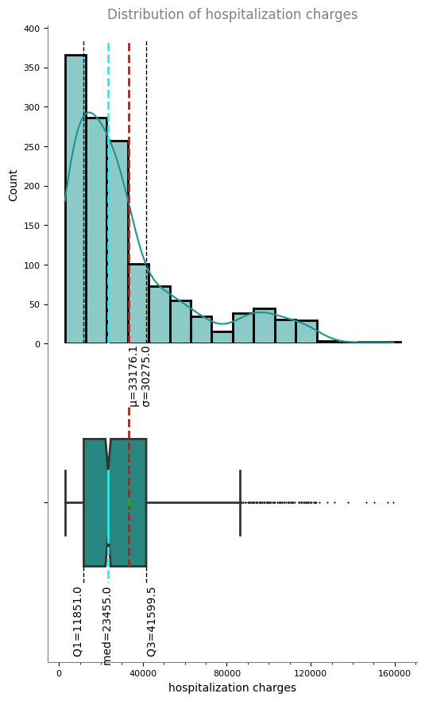

```python
custom_plot_numeric_distribution(df, 'hospitalization charges', 'title_', box_major=40000, box_minor=10000).show()
```

## Univariate and Bi-Variate Analysis

Hospitalization Charges

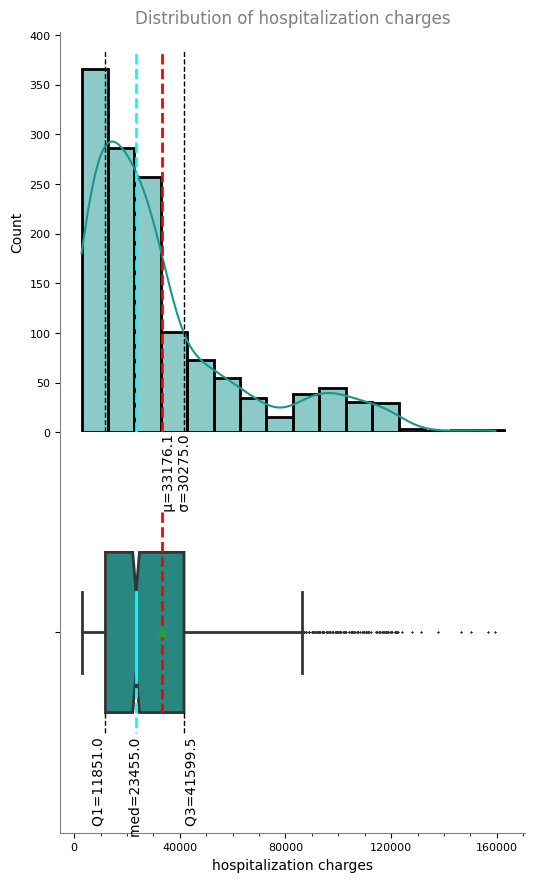

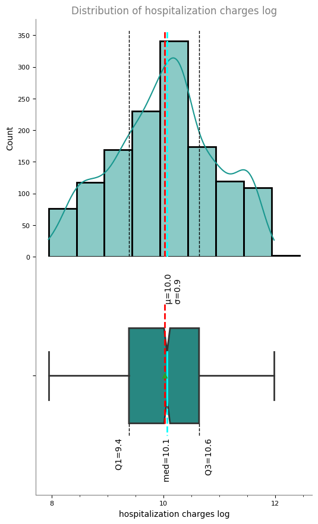

```python
custom_plot_numeric_distribution(df, 'hospitalization charges', 'title_', box_major=40000, box_minor=10000).show()
df['hospitalization charges log'] = np.log(df['hospitalization charges'])
custom_plot_numeric_distribution(df, 'hospitalization charges log', 'title_', box_major=2, box_minor=0.5).show()
```

Viral Load

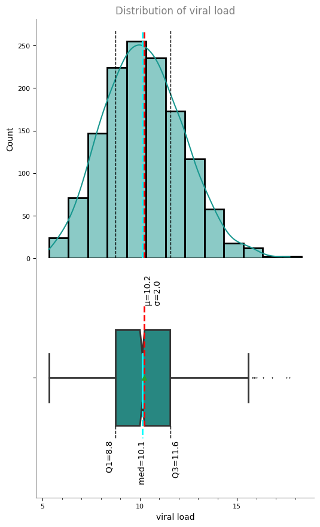

```python
custom_plot_numeric_distribution(df, 'viral load', 'title_', box_major=5, box_minor=1).show()
```

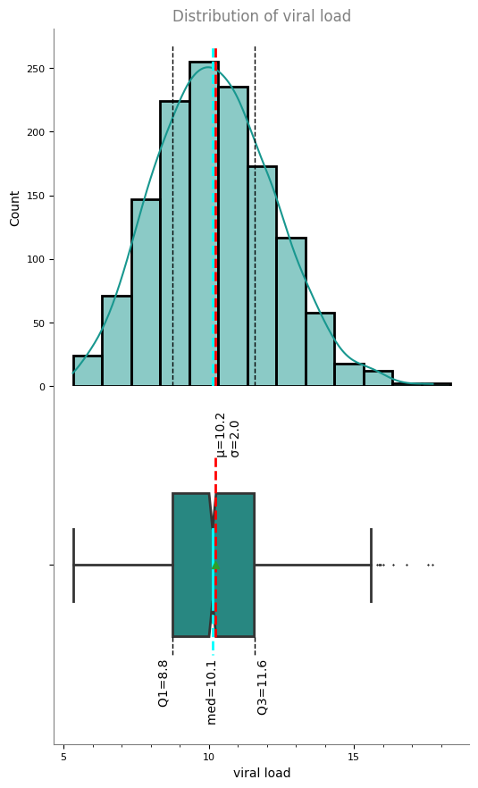

```python
custom_plot_numeric_distribution(df, 'viral load', 'title_', box_major=5, box_minor=1).show()
```

Age

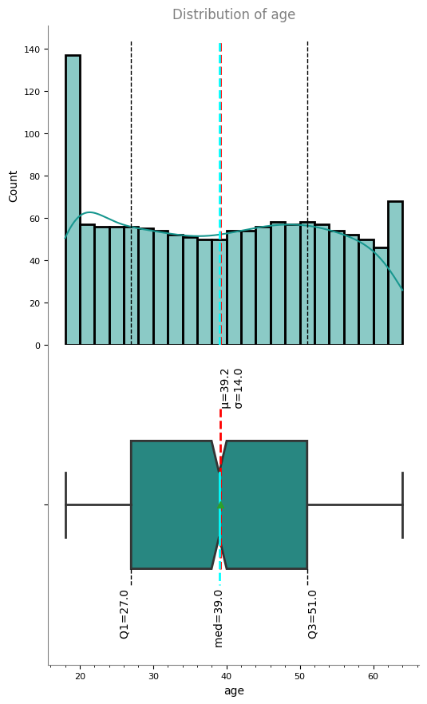

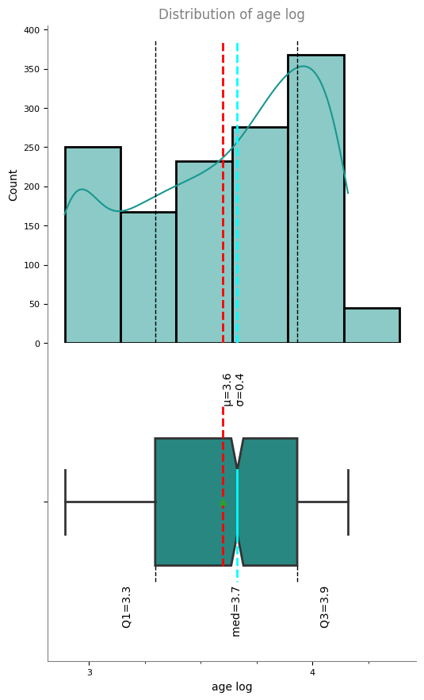

```python
custom_plot_numeric_distribution(df, 'age', 'title_', box_major=10, box_minor=2).show()
df['age log'] = np.log(df['age'])
custom_plot_numeric_distribution(df, 'age log', 'title_', box_major=1, box_minor=0.25).show()
```

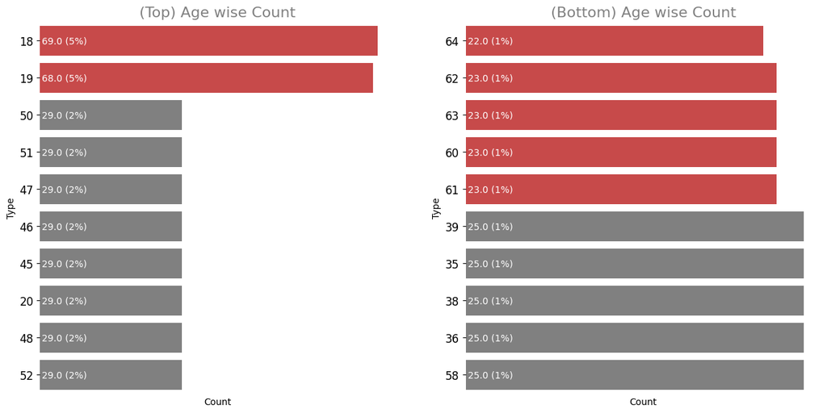

```python
fig = plt.figure()

ax1 = plt.subplot(1, 2, 1)
ax2 = plt.subplot(1, 2, 2)

custom_plt_most_least10_count_plot(ax1, df, '', 'age', '', '(Top) Age wise Count', 'Type', 'Count', unit_='', highlight_num=2, highlight_color='#DC3535', orientation_='h', agg_func='Count', agg_var=None, order_='top')
custom_plt_most_least10_count_plot(ax2, df, '', 'age', '', '(Bottom) Age wise Count', 'Type', 'Count', unit_='', highlight_num=5, highlight_color='#DC3535', orientation_='h', agg_func='Count', agg_var=None, order_='bottom')

plt.show()
```

Sex

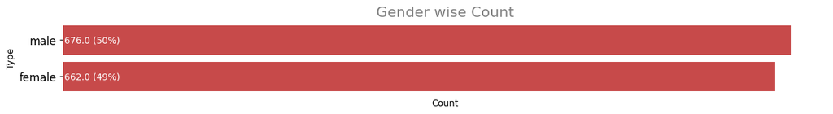

```python
custom_plt_most_least10_count_plot(plt.subplot(), df, '', 'sex', '', 'Gender wise Count', 'Type', 'Count', unit_='', highlight_num=None, highlight_color='#DC3535', orientation_='h', agg_func='Count', agg_var=None).show()
```

Smoker

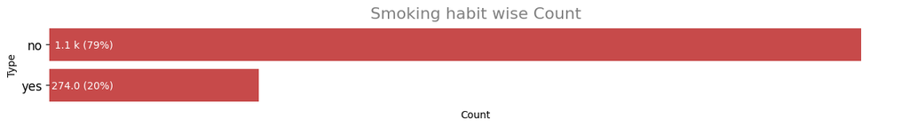

```python
custom_plt_most_least10_count_plot(plt.subplot(), df, '', 'smoker', '', 'Smoking habit wise Count', 'Type', 'Count', unit_='', highlight_num=None, highlight_color='#DC3535', orientation_='h', agg_func='Count', agg_var=None).show()
```

Region

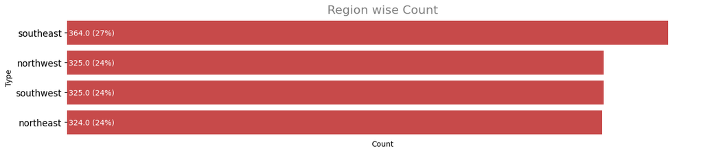

```python
custom_plt_most_least10_count_plot(plt.subplot(), df, '', 'region', '', 'Region wise Count', 'Type', 'Count', unit_='', highlight_num=None, highlight_color='#DC3535', orientation_='h', agg_func='Count', agg_var=None).show()
```

Severity Level

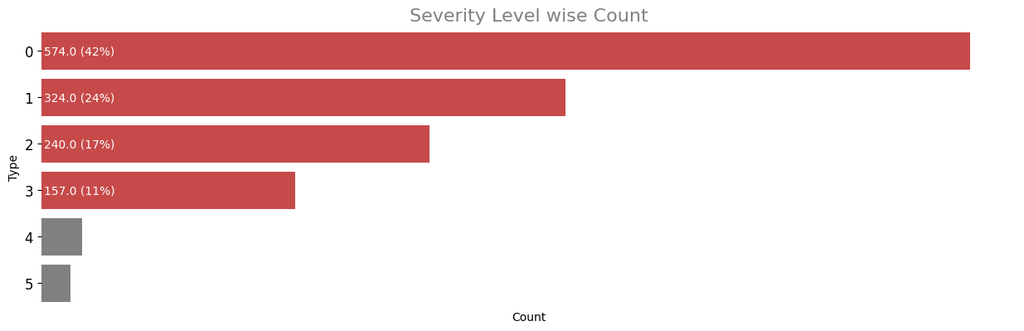

```python
custom_plt_most_least10_count_plot(plt.subplot(), df, '', 'severity level', '', 'Severity Level wise Count', 'Type', 'Count', unit_='', highlight_num=None, highlight_color='#DC3535', orientation_='h', agg_func='Count', agg_var=None).show()
```

Hospitalization charges vs age and viral load (and other categorical variables)

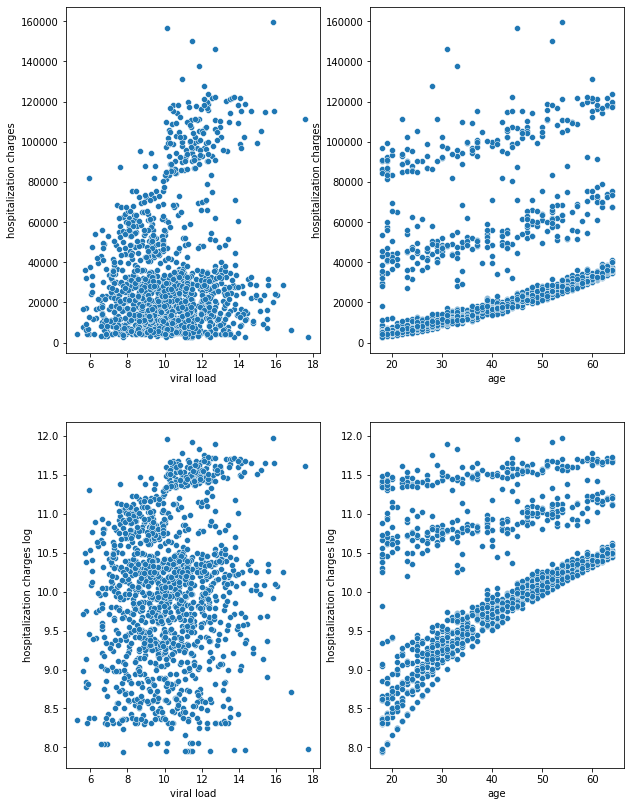

```python
fig, ax = plt.subplots(2, 2, figsize=(10, 14))

sns.scatterplot(data = df, x = 'viral load', y = 'hospitalization charges', ax=ax[0, 0])
sns.scatterplot(data = df, x = 'age', y = 'hospitalization charges', ax=ax[0, 1])

sns.scatterplot(data = df, x = 'viral load', y = 'hospitalization charges log', ax=ax[1, 0])
sns.scatterplot(data = df, x = 'age', y = 'hospitalization charges log', ax=ax[1, 1])
plt.show()
```

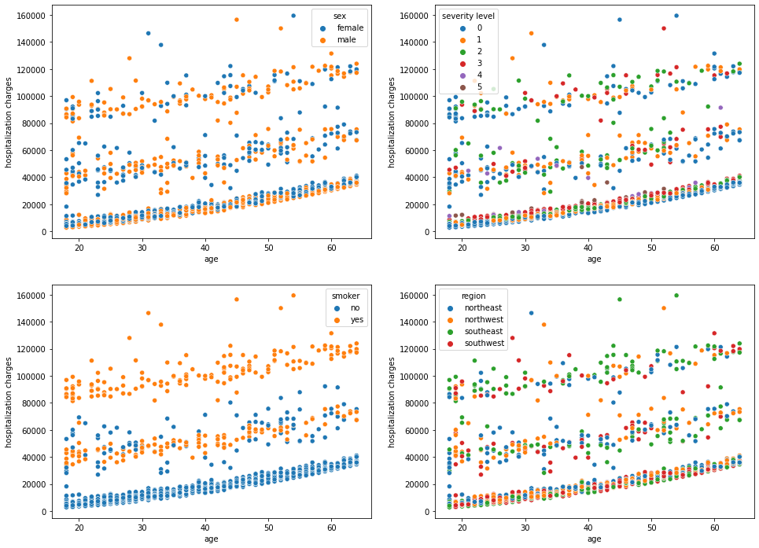

```python
fig, axs = plt.subplots(nrows=2, ncols=2, figsize=(16, 12))

sns.scatterplot(y='hospitalization charges', x='age', data=df, hue='sex', ax=axs[0, 0])
sns.scatterplot(y='hospitalization charges', x='age', data=df, hue='severity level', ax=axs[0,1])
sns.scatterplot(y='hospitalization charges', x='age', data=df, hue='smoker', ax=axs[1,0])
sns.scatterplot(y='hospitalization charges', x='age', data=df, hue='region', ax=axs[1,1])
plt.show()
```

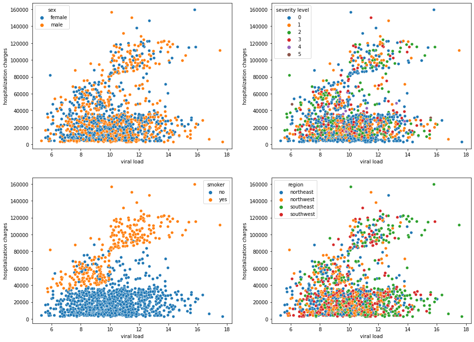

```python
fig, axs = plt.subplots(nrows=2, ncols=2, figsize=(16, 12))

sns.scatterplot(y='hospitalization charges', x='viral load', data=df, hue='sex', ax=axs[0, 0])
sns.scatterplot(y='hospitalization charges', x='viral load', data=df, hue='severity level', ax=axs[0,1])
sns.scatterplot(y='hospitalization charges', x='viral load', data=df, hue='smoker', ax=axs[1,0])
sns.scatterplot(y='hospitalization charges', x='viral load', data=df, hue='region', ax=axs[1,1])
plt.show()
```

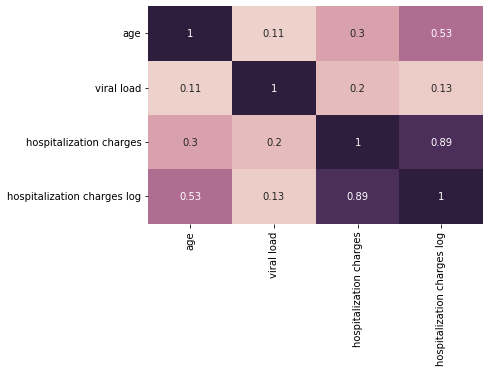

```python
sns.heatmap(df.corr(), annot=True, cbar=False, cmap=sns.cubehelix_palette(as_cmap=True))
plt.show()
```

## Hypothesis Testing

Assume, Significance Level ($\alpha$) as 0.05. We assume that the observations are independant of each other.

It is observed that 'Hospitalization Chages' feature visually appear to be log normally distributed, where as 'Viral Load' feature is normally distributed. 'Age' is uniformly distributed.

We can assume, 'Hospitalization Chages' feature is log normally distributed and 'Viral Load' feature is normally distributed.

We will check for equal variance using Levene statistical Test

**Test 1 (Right Tailed Two Sample t Test)**

H0 = Mean of hospitalization charges for smokers and non-smokers are not significantly different

Ha = Mean of hospitalization charges for smokers is significantly greater than that for non-smokers

[figure not shown]

```python
custom_plot_kde_distribution(plt.subplot(), df, 'smoker', 'hospitalization charges log', 'Season wise Count', 'count', 'Density').show()
```

Visullay the distribution does not look gaussian. We will confirm our observation using Shapiro-Wilk Test.

```python
stats.shapiro(df.loc[df['smoker']=='yes', 'hospitalization charges log'])
```

```
ShapiroResult(statistic=0.9288101196289062, pvalue=3.4734257137181146e-10)
```

```python
stats.shapiro(df.loc[df['smoker']=='no', 'hospitalization charges log'])
```

```
ShapiroResult(statistic=0.9761605858802795, pvalue=3.2253915250440857e-12)
```

Since p_value < significance level; distributions are not normal. But the distributions are approximately normal. We will proceed with the t-test assuming that the distributions are normal.

```python
stats.levene(df.loc[df['smoker']=='yes', 'hospitalization charges log'], df.loc[df['smoker']=='no', 'hospitalization charges log'])
```

```
LeveneResult(statistic=89.49584320261768, pvalue=1.332832802389931e-20)
```

Since p_value < significance level; we observe unequal variances

```python
stats.ttest_ind(df.loc[df['smoker']=='yes', 'hospitalization charges log'], df.loc[df['smoker']=='no', 'hospitalization charges log'], equal_var=False, alternative='greater')
```

```
Ttest_indResult(statistic=46.37082591943892, pvalue=1.9600240968860024e-234)
```

Since p_value < significance level; mean of hospitalization charges for smokers is significantly greater than that for non-smokers

**Test 2 (Two Tailed Two Sample t Test)**

H0 = Mean of viral load for females and males are not significantly different

Ha = Mean of viral load for females and males are significantly different

[figure not shown]

```python
custom_plot_kde_distribution(plt.subplot(), df, 'sex', 'viral load', 'Season wise Count', 'count', 'Density').show()
```

Visullay both the distribution look nealy identical and gaussian distributed.

```python
stats.shapiro(df.loc[df['sex']=='female', 'viral load'])
```

```
ShapiroResult(statistic=0.9930474162101746, pvalue=0.003624602919444442)
```

```python
stats.shapiro(df.loc[df['sex']=='male', 'viral load'])
```

```
ShapiroResult(statistic=0.9930650591850281, pvalue=0.003189612179994583)
```

```python
stats.levene(df.loc[df['sex']=='female', 'viral load'], df.loc[df['sex']=='male', 'viral load'])
```

```
LeveneResult(statistic=0.0038754151966871046, pvalue=0.9503708012456551)
```

Since p_value > significance level; we can assume equal variances

```python
stats.ttest_ind(df.loc[df['sex']=='female', 'viral load'], df.loc[df['sex']=='male', 'viral load'], equal_var=True, alternative='two-sided')
```

```
Ttest_indResult(statistic=-1.695711164450323, pvalue=0.0901735841670204)
```

Since p_value > significance level; mean of viral load for females and males are not significantly different